# Tarea 4

m1ch3ll3

3/4/2018

## Entregables

### Foto de mi cluster

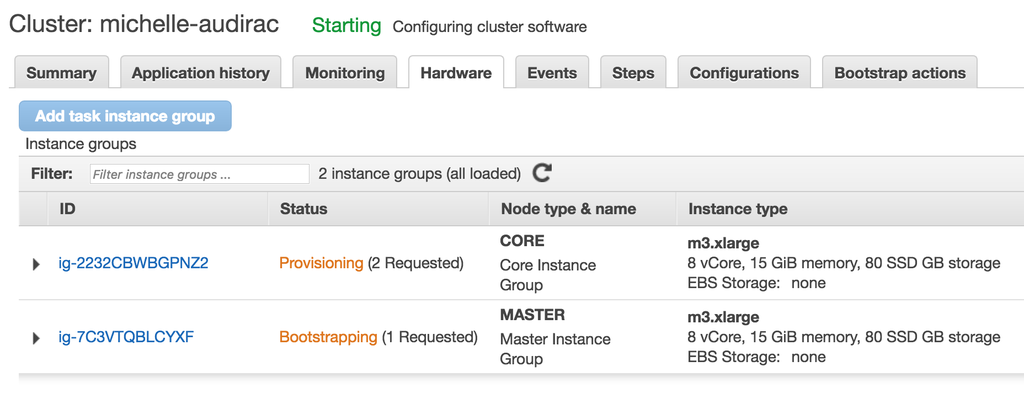

### Ejercicio a

Modifica el ejercicio de Rank para que en lugar de obtener el id del producto con mejor rank obtengamos el nombre del producto -requieres un join- con el mejor rank

- pig query

```bash
cat ./a/a.pig
```

```
## order_details = load 's3://audiracmichelle/northwind/order_details.csv' using PigStorage(',') as (orderid:chararray, productid:chararray, unitprice:float, quantity:int, discount:float);
## order_details = foreach order_details generate productid;
##
## products = load 's3://audiracmichelle/northwind/products.csv' using PigStorage(',') as (productid:chararray, productname:chararray, supplierid:chararray, categoryid:chararray, quantityperunit:int, unitprice:float, unitsinstock:int, unitsonorder:int, reorderlevel:int, discounted:int);
## products = foreach products generate ..productname;
##
## order_details = JOIN order_details by productid, products by productid;
##
## group_products = group order_details by $2;
## count_products = FOREACH group_products GENERATE $0 as productname, COUNT($1) as n;
##
## ranked = rank count_products by n DESC;
## ranked = limit ranked 10;
##
## store ranked into 's3://audiracmichelle/a/output/' using PigStorage(',');
```

El output se encuentra en ./a/output y se ve así

```bash
cat ./a/output/*
```

```
## 1,Raclette Courdavault,54
## 2,Camembert Pierrot,51
## 2,Guaran<c3><a1> Fant<c3><a1>stica,51
## 2,Gorgonzola Telino,51
## 5,Gnocchi di nonna Alice,50
## 6,Tarte au sucre,48
## 7,Jack's New England Clam Chowder,47
## 8,Rh<c3><b6>nbr<c3><a4>u Klosterbier,46
## 9,Chang,44
## 10,Pavlova,43
```

### Ejercicio b1

1. ¿Cuántos vuelos existen en el dataset cuyo aeropuerto destino sea el “Honolulu International Airport”?
- pig query

```bash
cat ./b1/b1.pig
```

```
## flights = load 's3://audiracmichelle/flights/flights.csv' using PigStorage(',') as (year:int, month:int, day:int, day_of_week:int, airline:chararray, flight_number:int, tail_number:chararray, origin_airport:chararray, destination_airport:chararray, scheduled_departure:int, departure_time:int, dep…
##
## flights = foreach flights generate origin_airport;
## HNL = filter flights by origin_airport in ('HNL');
##
## group_HNL = group HNL by $0;
## n_HNL = FOREACH group_HNL GENERATE COUNT($1);
##
## store n_HNL into 's3://audiracmichelle/b1/output/' using PigStorage(',');
```

- El output se encuentra en ./b1/output

```bash
cat ./b1/output/*
```

```
## 43172
```

### Ejercicio b2

2. ¿Cuál es el vuelo con más retraso? ¿De qué aerolínea es?
- pig query

```bash
cat ./b2/b2.pig
```

```
## flights = load 's3://audiracmichelle/flights/flights.csv' using PigStorage(',') as (year:int, month:int, day:int, day_of_week:int, airline:chararray, flight_number:int, tail_number:chararray, origin_airport:chararray, destination_airport:chararray, scheduled_departure:int, departure_time:int, dep…
##
## flights = foreach flights generate airline, flight_number, departure_delay;
## flights = order flights by departure_delay DESC;
## max = limit flights 1;
##
## store max into 's3://audiracmichelle/b2/output/' using PigStorage(',');
```

- El output se encuentra en ./b2/output

El vuelo con más retraso (departure_delay) es el vuelo 1322 de American Airlines.

```bash
cat ./b2/output/*
```

```
## AA,1322,1988
```

### Ejercicio b3

3. ¿Qué día es en el que más vuelos cancelados hay?
- pig query

```bash
cat ./b3/b3.pig
```

```
## flights = load 's3://audiracmichelle/flights/flights.csv' using PigStorage(',') as (year:int, month:int, day:int, day_of_week:int, airline:chararray, flight_number:int, tail_number:chararray, origin_airport:chararray, destination_airport:chararray, scheduled_departure:int, departure_time:int, dep…
##
## group_flights = group flights by (year, month, day);
##
## cancellations = foreach group_flights generate group.year, group.month, group.day, SUM(flights.cancelled) as sum_cancelled;
##
## cancellations = order cancellations by sum_cancelled DESC;
## max = limit cancellations 5;
##
## store max into 's3://audiracmichelle/b3/output/' using PigStorage(',');
```

- El output se encuentra en ./b3/output

El día con más vuelos cancelados es el 27 de enero de 2015.

Aquí los cinco días con más vuelos cancelados:

```bash
cat ./b3/output/*
```

```
## 2015,1,27,2884
## 2015,3,5,2858
## 2015,2,2,2799
## 2015,12,28,2177
## 2015,2,1,1979
```

### Ejercicio b4

4. ¿Cuáles son los aeropuertos orígen con 17 cancelaciones?
- pig query

```bash
cat ./b4/b4.pig
```

```
## flights = load 's3://audiracmichelle/flights/flights.csv' using PigStorage(',') as (year:int, month:int, day:int, day_of_week:int, airline:chararray, flight_number:int, tail_number:chararray, origin_airport:chararray, destination_airport:chararray, scheduled_departure:int, departure_time:int, dep…
##
## group_flights = group flights by origin_airport;
##
## cancellations = foreach group_flights generate $0, SUM(flights.cancelled) as sum_cancelled;
## cancellations = filter cancellations by sum_cancelled == 17;
##
## store cancellations into 's3://audiracmichelle/b4/output/' using PigStorage(',');
```

- El output se encuentra en ./b4/output

Los aeropuertos orígen con 17 cancelaciones son:

Dothan Regional Airport

Dickinson Theodore Roosevelt Regional Airport

Delta County Airport

```bash
cat ./b4/output/*
```

```
## DHN,17
## DIK,17
## ESC,17
## 14107,17
```

### Ejercicio b5

5. ¿Cuál es el aeropuerto origen con más vuelos cancelados?
- pig query

```bash
cat ./b5/b5.pig
```

```
## flights = load 's3://audiracmichelle/flights/flights.csv' using PigStorage(',') as (year:int, month:int, day:int, day_of_week:int, airline:chararray, flight_number:int, tail_number:chararray, origin_airport:chararray, destination_airport:chararray, scheduled_departure:int, departure_time:int, dep…
##
## group_flights = group flights by origin_airport;
##
## cancellations = foreach group_flights generate $0, SUM(flights.cancelled) as sum_cancelled;
## cancellations = order cancellations by sum_cancelled DESC;
## max = limit cancellations 1;
##
## store max into 's3://audiracmichelle/b5/output/' using PigStorage(',');
```

- El output se encuentra en ./b5/output

Los aeropuertos orígen con más vuelos cancelados es:

Chicago O’Hare International Airport

```bash
cat ./b5/output/*
```

```
## ORD,8548
```

### Ejercicio b6

6. ¿Cuál es el vuelo (flight number) con mayor diversidad de aeropuertos destino, cuáles son estos destinos? (ocupar bag te ayudará en esta pregunta)
- pig query

```bash
cat ./b6/b6.pig
```

```
## flights = load 's3://audiracmichelle/flights/flights.csv' using PigStorage(',') as (year:int, month:int, day:int, day_of_week:int, airline:chararray, flight_number:int, tail_number:chararray, origin_airport:chararray, destination_airport:chararray, scheduled_departure:int, departure_time:int, dep…
##
## destinations = foreach (group flights by flight_number){d = DISTINCT flights.destination_airport; generate group as flight_number, COUNT(d) as n, d;};
## destinations = order destinations by n DESC;
##
## max = limit destinations 5;
##
## store max into 's3://audiracmichelle/b6/output/' using PigStorage(',');
```

- El output se encuentra en ./b6/output

```bash
cat ./b6/output/*
```

```
## 202,68,{(10140),(10397),(10423),(10693),(10721),(10821),(11292),(11433),(11986),(12266),(12402),(12478),(13232),(13487),(13830),(13930),(14057),(14100),(14107),(14122),(14683),(14747),(14831),(ATL),(AUS),(BDL),(BNA),(BOS),(BWI),(CAK),(CLE),(DCA),(DEN),(DTW),(EWR),(FLL),(FNT),(IAD),(IAH),(IND),(IT…
## 1196,65,{(10693),(11259),(11298),(11618),(12892),(12953),(13204),(13232),(13830),(13930),(14307),(14679),(14747),(ALB),(ATL),(AUS),(BNA),(BOS),(BWI),(BZN),(CLE),(CMH),(CVG),(DAL),(DAY),(DCA),(DEN),(DFW),(DSM),(DTW),(EGE),(EWR),(FLL),(GSO),(IAD),(IAH),(IND),(LAS),(LAX),(LGA),(MCI),(MCO),(MDW),(MIA…
## 4988,64,{(10821),(11057),(11292),(11921),(11996),(12892),(13851),(13871),(14457),(14908),(ACV),(ATL),(ATW),(AUS),(BDL),(BGR),(BIL),(BOS),(BWI),(BZN),(CHA),(CHS),(CID),(DEN),(DRO),(DSM),(DTW),(FAR),(GJT),(GSO),(GSP),(GUC),(HOU),(HSV),(IAH),(ICT),(ISN),(ISP),(LAX),(LGA),(MCO),(MLI),(MRY),(MSP),(MSY…
## 1214,63,{(10140),(10397),(10721),(11057),(11259),(11292),(11433),(11618),(11697),(13495),(13930),(14100),(14679),(ABQ),(AGS),(ALB),(ATL),(AVL),(BOS),(BWI),(CLE),(DAL),(DCA),(DEN),(DFW),(DTW),(EWR),(FLL),(GRR),(GSO),(HOU),(IAD),(IAH),(ICT),(LAS),(LAX),(LGA),(MAF),(MCO),(MDW),(MEM),(MIA),(MKE),(MSN…
## 1132,62,{(10397),(10620),(10721),(11252),(12892),(14100),(14107),(14321),(14679),(15016),(ABQ),(ALB),(ATL),(AUS),(BIL),(BNA),(BOS),(BWI),(BZN),(CMH),(DAL),(DAY),(DCA),(DEN),(DFW),(DTW),(EWR),(GEG),(IAD),(IAH),(ICT),(LAS),(LAX),(LEX),(MCO),(MDW),(MEM),(MHT),(MIA),(MSP),(ONT),(ORD),(PBI),(PDX),(PHL…
```